# Introduction to Dynamic Factor Analysis

SOE 592 – Intro to Time Series Analysis

5 Jan 2024

# Introduction

DFA is conceptually different than what we have been doing in the previous applications. Here we are trying to explain temporal variation in a set of $n$ observed time series using linear combinations of a set of $m$ hidden random walks, where $m << n$. A DFA model is a type of MARSS model with the following structure:

$$\begin{equation}
\begin{gathered}
\mathbf{y}_t = \mathbf{Z}\mathbf{x}_t + \mathbf{a} +
\mathbf{D}\mathbf{d}_t + \mathbf{v}_t \text{ where } \mathbf{v}_t \sim
\text{MVN}(0,\mathbf{R}) \\
\mathbf{x}_t = \mathbf{x}_{t-1}+\mathbf{w}_t \text{ where } \mathbf{w}_t
\sim \text{MVN}(0,\mathbf{Q}) \\
\end{gathered}
\end{equation}$$

This equation should look rather familiar as it is exactly the same form we used for estimating varying number of processes from a set of observations in earlier lessons. The difference with DFA is that rather than fixing the elements within $\mathbf{Z}$ at 1 or 0 to indicate whether an observation does or does not correspond to a trend, we will instead estimate them as “loadings” on each of the states/processes.

# Example of a DFA model

The general idea is that the observations $\mathbf{y}$ are modeled as a linear combination of covariates $\mathbf{Dd}_t$, hidden processes $\mathbf{x}$ and factor loadings $\mathbf{Z}$, and some offsets $\mathbf{a}$. Ignoring for now the effect(s) of covariates, imagine a case where we had a data set with five observed time series ($n = 5$) and we want to fit a model with three hidden processes ($m = 3$). If we write out our DFA model in MARSS matrix form, the observation equation would look like

$$\begin{equation}
\begin{bmatrix}
y_{1} \\
y_{2} \\
y_{3} \\
y_{4} \\
y_{5} \end{bmatrix}_t =
\begin{bmatrix}
z_{11}&z_{12}&z_{13}\\
z_{21}&z_{22}&z_{23}\\
z_{31}&z_{32}&z_{33}\\
z_{41}&z_{42}&z_{43}\\
z_{51}&z_{52}&z_{53}\end{bmatrix}
\begin{bmatrix}
x_{1} \\
x_{2} \\
x_{3} \end{bmatrix}_t +
\begin{bmatrix}
a_1 \\
a_2 \\
a_3 \\
a_4 \\
a_5 \end{bmatrix} +
\begin{bmatrix}
v_{1} \\
v_{2} \\
v_{3} \\
v_{4} \\
v_{5} \end{bmatrix}_t.
\end{equation}$$

and the process model would look like

$$\begin{equation}
\begin{bmatrix}
x_{1} \\
x_{2} \\
x_{3} \end{bmatrix}_t =
\begin{bmatrix}
1&0&0 \\
0&1&0 \\
0&0&1 \end{bmatrix}
\begin{bmatrix}
x_{1}\\
x_{2}\\
x_{3}\end{bmatrix}_{t-1} +
\begin{bmatrix}
w_{1} \\
w_{2} \\
w_{3} \end{bmatrix}_t
\end{equation}$$

The observation errors would be

$$\begin{equation}
\begin{bmatrix}
v_{1} \\
v_{2} \\
v_{3} \\
v_{4} \\
v_{5} \end{bmatrix}_t
\sim \text{MVN} \begin{pmatrix}
\begin{bmatrix}
0 \\
0 \\
0 \\
0 \\
0 \end{bmatrix},
\begin{bmatrix}
r_{11}&r_{12}&r_{13}&r_{14}&r_{15}\\
r_{12}&r_{22}&r_{23}&r_{24}&r_{25}\\
r_{13}&r_{23}&r_{33}&r_{34}&r_{35}\\
r_{14}&r_{24}&r_{34}&r_{44}&r_{45}\\
r_{15}&r_{25}&r_{35}&r_{45}&r_{55}\end{bmatrix}
\end{pmatrix}
\end{equation}$$

And the process errors would be

$$\begin{equation}
\begin{bmatrix}
w_{1} \\
w_{2} \\
w_{3} \end{bmatrix}_t
\sim \text{MVN} \begin{pmatrix}
\begin{bmatrix}
0 \\
0 \\
0 \end{bmatrix},
\begin{bmatrix}
q_{11}&q_{12}&q_{13}\\
q_{12}&q_{22}&q_{23}\\
q_{13}&q_{23}&q_{33}\end{bmatrix}
\end{pmatrix}.
\end{equation}$$

# Constraining a DFA model

If $\mathbf{a}$, $\mathbf{Z}$, and $\mathbf{Q}$ are not constrained, the DFA model above is unidentifiable. Nevertheless, we can use the following parameter constraints to make the model identifiable:

- $\mathbf{a}$ is constrained so that the first $m$ values are set to zero;
- in the first $m-1$ rows of $\mathbf{Z}$, the $z$-value in the $j$-th column and $i$-th row is set to zero if $j > i$; and
- $\mathbf{Q}$ is set equal to the identity matrix $\mathbf{I}_m$.

Using these constraints, the observation equation for the DFA model above becomes

$$\begin{equation}
\begin{bmatrix}
y_{1} \\
y_{2} \\
y_{3} \\
y_{4} \\
y_{5} \end{bmatrix}_t =
\begin{bmatrix}
z_{11}&0&0\\
z_{21}&z_{22}&0\\
z_{31}&z_{32}&z_{33}\\
z_{41}&z_{42}&z_{43}\\
z_{51}&z_{52}&z_{53}\end{bmatrix}
\begin{bmatrix}
x_{1} \\
x_{2} \\
x_{3} \end{bmatrix}_t +
\begin{bmatrix}
0 \\
0 \\
0 \\
0 \\
0 \end{bmatrix} +
\begin{bmatrix}
v_{1} \\
v_{2} \\
v_{3} \\
v_{4} \\
v_{5} \end{bmatrix}_t.
\end{equation}$$

and the process equation becomes

$$\begin{equation}
\begin{bmatrix}
x_{1} \\
x_{2} \\
x_{3} \end{bmatrix}_t =
\begin{bmatrix}
1&0&0 \\
0&1&0 \\
0&0&1 \end{bmatrix}
\begin{bmatrix}
x_{1}\\
x_{2}\\
x_{3}\end{bmatrix}_{t-1} +
\begin{bmatrix}
w_{1} \\
w_{2} \\
w_{3}
\end{bmatrix}_t
\end{equation}$$

The distribution of the observation errors would stay the same, such that

$$\begin{equation}
\begin{bmatrix}
v_{1} \\
v_{2} \\
v_{3} \\
v_{4} \\
v_{5} \end{bmatrix}_t
\sim \text{MVN} \begin{pmatrix}
\begin{bmatrix}
0 \\
0 \\
0 \\
0 \\
0 \end{bmatrix},
\begin{bmatrix}
r_{11}&r_{12}&r_{13}&r_{14}&r_{15}\\
r_{12}&r_{22}&r_{23}&r_{24}&r_{25}\\
r_{13}&r_{23}&r_{33}&r_{34}&r_{35}\\
r_{14}&r_{24}&r_{34}&r_{44}&r_{45}\\
r_{15}&r_{25}&r_{35}&r_{45}&r_{55}
\end{bmatrix}
\end{pmatrix}.
\end{equation}$$

but the distribution of the process errors would become

$$\begin{equation}
\begin{bmatrix}
w_{1} \\
w_{2} \\
w_{3} \end{bmatrix}_t
\sim \text{MVN}
\begin{pmatrix}
\begin{bmatrix}
0 \\
0 \\
0 \end{bmatrix},
\begin{bmatrix}
1&0&0 \\
0&1&0 \\
0&0&1 \end{bmatrix}
\end{pmatrix},
\end{equation}$$

# Different error structures

The example observation equation we used above had what we refer to as an “unconstrained” variance-covariance matrix $\mathbf{R}$ wherein all of the parameters are unique. In certain applications, however, we may want to change our assumptions about the forms for $\mathbf{R}$. For example, we might have good reason to believe that all of the observations have different error variances and they were independent of one another (e.g., different methods were used for sampling), in which case

$$\mathbf{R} =
\begin{bmatrix}
r_1&0&0&0&0 \\
0&r_2&0&0&0 \\
0&0&r_3&0&0 \\
0&0&0&r_4&0 \\
0&0&0&0&r_5
\end{bmatrix}.$$

Alternatively, we might have a situation where all of the observation errors had the same variance $r$, but they were not independent from one another. In that case we would have to include a covariance parameter $k$, such that

$$\mathbf{R} =
\begin{bmatrix}
r&k&k&k&k \\
k&r&k&k&k \\
k&k&r&k&k \\
k&k&k&r&k \\
k&k&k&k&r
\end{bmatrix}.$$

Any of these options for $\mathbf{R}$ (and other custom options as well) are available to us in a DFA model, just as they were in the MARSS models used in previous chapters.

# Lake Washington phytoplankton

For this exercise, we will use the Lake Washington phytoplankton data contained in the {MARSS} package.

**Task:** Begin by reading in the monthly values for all of the data, including metabolism, chemistry, and climate.

```r
## load MARSS
library(MARSS)

## load the data (there are 3 datasets contained here)
data(lakeWAplankton, package = "MARSS")

## we want lakeWAplanktonTrans, which has been transformed
## so the 0s are replaced with NAs and the data z-scored
all_dat <- lakeWAplanktonTrans

## use only the 10 years from 1980-1989
yr_frst <- 1980
yr_last <- 1989
plank_dat <- all_dat[all_dat[, "Year"] >= yr_frst &
                     all_dat[, "Year"] <= yr_last,]

## create vector of phytoplankton group names
phytoplankton <- c("Cryptomonas", "Diatoms", "Greens",
                   "Unicells", "Other.algae")

## get only the phytoplankton
dat_1980 <- plank_dat[, phytoplankton]
```

**Task:** Transpose the data matrix and calculate the number of time series and their length.

```r
## transpose data so time goes across columns
dat_1980 <- t(dat_1980)

## get number of time series
N_ts <- dim(dat_1980)[1]

## get length of time series
TT <- dim(dat_1980)[2]
```

**Task:** It will be easier to estimate the real parameters of interest if we de-mean the data, so let’s do that.

```r
## mean of each taxon
y_bar <- apply(dat_1980, 1, mean, na.rm = TRUE)

## subtract the means
dat <- dat_1980 - y_bar

## assign new column names
spp <- rownames(dat_1980)
rownames(dat) <- spp
```

## Plots of the data

**Task:** Create time series plots of all five phytoplankton functional groups.

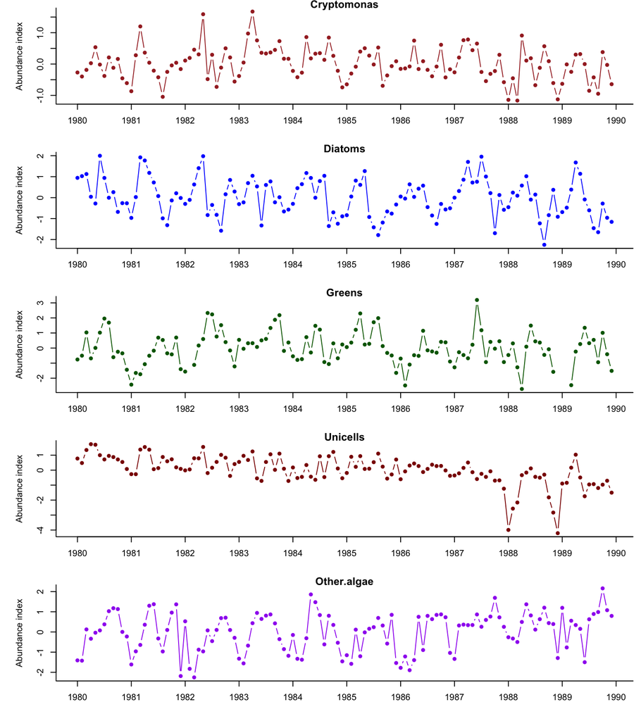

Demeaned time series of Lake Washington phytoplankton.

```r
## set plot colors
clr <- c("brown", "blue", "darkgreen", "darkred", "purple")

## initialize a counter
cnt <- 1

## set up plotting space & make plots
par(mfrow = c(N_ts, 1), mai = c(0.5, 0.7, 0.1, 0.1), omi = c(0, 0, 0, 0))

for(i in spp){
  plot(dat[i,],  bty = "L", xaxt = "n", pch = 16,
       xlab = "",
       ylab = "Abundance index", col=clr[cnt], type="b")
  axis(1, 12 * (0:dim(dat_1980)[2]) + 1, yr_frst + 0:dim(dat_1980)[2])
  title(i)
  cnt <- cnt + 1
  }
```

# Fitting DFA models with {MARSS}

The {MARSS} package is designed to work with the fully specified matrix form of the multivariate state-space model we wrote out in Sec 3. Thus, we will need to create a model list with forms for each of the vectors and matrices.

**Note:** Even though some of the model elements are scalars and vectors, we will need to specify everything as a matrix (or array for time series of matrices).

**Tip:** The code below uses some of the {MARSS} shortcuts for specifying forms of vectors and matrices. We will also use the `matrix(list(), nrow, ncol)` trick we learned previously.

## The observation model

Here we will fit the DFA model above where we have 5 observed time series and we want 3 hidden states. Now we need to set up the observation model for `MARSS()`. Here are the vectors and matrices for our first model where each nutrient follows its own process. Recall that we will need to set the elements in the upper R corner of $\mathbf{Z}$ to 0. We will assume that the observation errors have different variances and they are independent of one another.

```r
## `ZZ` is loadings matrix; upper right triangle contains 0's
Z_vals <- list("z11",  0  ,  0  ,
               "z21","z22",  0  ,
               "z31","z32","z33",
               "z41","z42","z43",
               "z51","z52","z53")
ZZ <- matrix(Z_vals, nrow = N_ts, ncol = 3, byrow = TRUE)

## `aa` is the offset/scaling
aa <- "zero"

## `DD` and `d` are for covariates; 0 for now
DD <- "zero"
dd <- "zero"

## `RR` is variance-covariance matrix for obs errors
RR <- "diagonal and unequal"
```

## The process model

Just as with other MARSS models, we need to specify the explicit form for all of the vectors and matrices based on the full form of the MARSS model we defined above.

**Note:** We do not have to specify anything for the states $(\mathbf{x})$ – those are elements that `MARSS()` will identify and estimate itself based on our definitions of the other vectors and matrices.

```r
## number of processes
mm <- 3

## `BB` is identity: 1's along the diagonal & 0's elsewhere

BB <- "identity"  # diag(mm)

## `uu` is a column vector of 0's
uu <- "zero"  # matrix(0, mm, 1)

## `CC` and `cc` are for covariates
CC <- "zero"  # matrix(0, mm, 1)
cc <- "zero"  # matrix(0, 1, wk_last)

## `QQ` is an identity matrix
QQ <- "identity"  # diag(mm)
```

## Fit the model

Now it’s time to fit our first DFA model.

**Tip:** To do so, we need to create three lists that we will need to pass to the `MARSS()` function:

1. A list of specifications for the model’s vectors and matrices;
2. A list of any initial values – `MARSS()` will pick its own otherwise;
3. A list of control parameters for the `MARSS()` function.

```r
## list with specifications for model vectors/matrices
mod_list <- list(Z = ZZ, A = aa, D = DD, d = dd, R = RR,
                 B = BB, U = uu, C = CC, c = cc, Q = QQ)

## list with model inits; everything set to 0
init_list <- list(x0 = matrix(rep(0, mm), mm, 1))

## list with model control parameters
con_list <- list(maxit = 3000, allow.degen = TRUE)
```

**Task:** Go ahead and fit the model.

```r
## fit MARSS
dfa_1 <- MARSS(y = dat,
               model = mod_list,
               inits = init_list,
               control = con_list)
```

```
## Success! abstol and log-log tests passed at 246 iterations.
## Alert: conv.test.slope.tol is 0.5.
## Test with smaller values (<0.1) to ensure convergence.
##
## MARSS fit is
## Estimation method: kem
## Convergence test: conv.test.slope.tol = 0.5, abstol = 0.001
## Estimation converged in 246 iterations.
## Log-likelihood: -692.9795
## AIC: 1425.959   AICc: 1427.42
##
##                             Estimate
## Z.z11                         0.2738
## Z.z21                         0.4487
## Z.z31                         0.3170
## Z.z41                         0.4107
## Z.z51                         0.2553
## Z.z22                         0.3608
## Z.z32                        -0.3690
## Z.z42                        -0.0990
## Z.z52                        -0.3793
## Z.z33                         0.0185
## Z.z43                        -0.1404
## Z.z53                         0.1317
## R.(Cryptomonas,Cryptomonas)   0.1638
## R.(Diatoms,Diatoms)           0.2913
## R.(Greens,Greens)             0.8621
## R.(Unicells,Unicells)         0.3080
## R.(Other.algae,Other.algae)   0.5000
## x0.X1                         0.2218
## x0.X2                         1.8155
## x0.X3                        -4.8097
## Initial states (x0) defined at t=0
##
## Standard errors have not been calculated.
## Use MARSSparamCIs to compute CIs and bias estimates.
```

# Interpreting the output

By now the `MARSS()` output should look familiar. The first 12 parameter estimates `Z.z##` are the loadings of each observed time series on the 3 hidden states. The next 5 estimates `R.(,)` are the variances of the observation errors $(v_{i,t})$. The last 3 values, `x0.X#`, are the estimates of the initial states at $t = 0$.

**Tip:** Recall that the estimates of the processes themselves (i.e., $\mathbf{x}$) are contained in one of the list elements in our fitted `MARSS` object. Specifically, they are in `mod_fit$states`, and their respective standard errors are in `mod_fit$states.se`. For the names of all of the other objects, type `names(dfa_1)`.

## Rotating trends and loadings

Before proceeding further, we need to address the constraints we placed on the DFA model in Sec 2.2. In particular, we arbitrarily constrained $\mathbf{Z}$ in such a way to choose only one of these solutions, but fortunately the different solutions are equivalent, and they can be related to each other by a rotation matrix $\mathbf{H}$.

Let $\mathbf{H}$ be any $m \times m$ non-singular matrix. The following are then equivalent DFA models:

$$\begin{equation}
\begin{gathered}
\mathbf{y}_t = \mathbf{Z}\mathbf{x}_t+\mathbf{a}+\mathbf{v}_t \\
\mathbf{x}_t = \mathbf{x}_{t-1}+\mathbf{w}_t
\end{gathered}
\end{equation}$$

and

$$\begin{equation}
\begin{gathered}
\mathbf{y}_t =
\mathbf{Z}\mathbf{H}^{-1}\mathbf{x}_t+\mathbf{a}+\mathbf{v}_t \\
\mathbf{H}\mathbf{x}_t =
\mathbf{H}\mathbf{x}_{t-1}+\mathbf{H}\mathbf{w}_t
\end{gathered}.
\end{equation}$$

**Tip:** There are many ways of doing factor rotations, but a common method is the “varimax”” rotation, which seeks a rotation matrix $\mathbf{H}$ that creates the largest difference between the loadings in $\mathbf{Z}$.

For example, imagine that row 3 in our estimated $\mathbf{Z}$ matrix was (0.2, 0.2, 0.2). That would mean that green algae were a mixture of equal parts of processes 1, 2, and 3. If instead row 3 was (0.8, 0.1, 0.05), this would make our interpretation of the model fits easier because we could say that green algae followed the first process most closely. The varimax rotation will find the $\mathbf{H}$ matrix that makes the rows in $\mathbf{Z}$ more like (0.8, 0.1, 0.05) and less like (0.2, 0.2, 0.2).

**Tip:** The varimax rotation is easy to compute because R has a built in function for this: `varimax()`. Interestingly, the function returns the inverse of $\mathbf{H}$, which we need anyway.

```r
## get the estimated ZZ
Z_est <- coef(dfa_1, type = "matrix")$Z

## get the inverse of the rotation matrix
H_inv <- varimax(Z_est)$rotmat
```

**Task:** Go ahead and rotate both $\mathbf{Z}$ and $\mathbf{x}$.

**Tip:** You can the `solve()` function to get the inverse of a matrix.

```r
## rotate factor loadings
Z_rot = Z_est %*% H_inv

## rotate processes
proc_rot = solve(H_inv) %*% dfa_1$states
```

# Estimated states and loadings

Here are plots of the three hidden processes (left column) and the loadings for each of phytoplankton groups (right column).

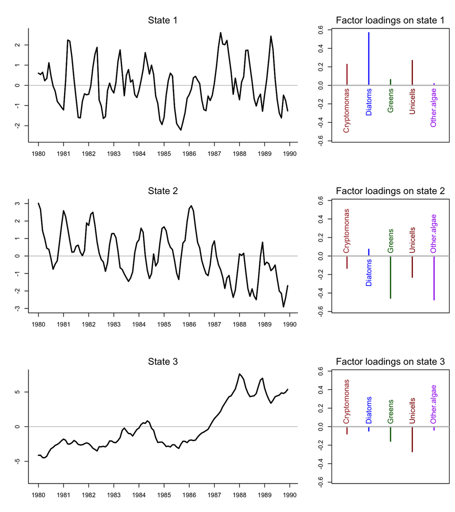

Estimated states from the DFA model.

```r
## plot labels
ylbl <- phytoplankton
w_ts <- seq(dim(dat)[2])

## set up plot area
layout(matrix(c(1,2,3,4,5,6), mm, 2), widths = c(2,1))
par(mai = c(0.5, 0.5, 0.5, 0.1), omi = c(0, 0, 0, 0))

## plot the processes
for(i in 1:mm) {
  ylm <- c(-1, 1) * max(abs(proc_rot[i,]))
  ## set up plot area
  plot(w_ts,proc_rot[i,], type = "n", bty = "L",
       ylim = ylm, xlab = "", ylab = "", xaxt = "n")
  ## draw zero-line
  abline(h = 0, col = "gray")
  ## plot trend line
  lines(w_ts, proc_rot[i,], lwd = 2)
  lines(w_ts, proc_rot[i,], lwd = 2)
  ## add panel labels
  mtext(paste("State",i), side = 3, line = 0.5)
  axis(1, 12 * (0:dim(dat_1980)[2]) + 1, yr_frst + 0:dim(dat_1980)[2])
}

## plot the loadings
## set minimum loading to actually plot
minZ <- 0
## set y-limits for plots
ylm <- c(-1, 1) * max(abs(Z_rot))
## cycle through the states
for(i in 1:mm) {
  plot(x = c(1:N_ts)[abs(Z_rot[,i]) > minZ],
       y = as.vector(Z_rot[abs(Z_rot[,i]) > minZ, i]),
       type = "h",
       lwd = 2, xlab = "", ylab = "", xaxt = "n", ylim = ylm,
       xlim = c(0.5, N_ts + 0.5), col = clr)
  for(j in 1:N_ts) {
    ## plot names above or below loadings
    if(Z_rot[j,i] > minZ) {
      text(j, -0.03, ylbl[j], srt = 90, adj = 1, cex = 1.2, col = clr[j])
      }
    if(Z_rot[j,i] < -minZ) {
      text(j, 0.03, ylbl[j], srt = 90, adj = 0, cex = 1.2, col = clr[j])
    }
    ## add horizontal line at 0
    abline(h = 0, lwd = 1.5, col = "gray")
  }
  ## add labels
  mtext(paste("Factor loadings on state", i), side = 3, line = 0.5)
}
```

It looks like there are strong seasonal cycles in the data, but there is some indication of a phase difference between some of the groups.

**Tip:** We can use the familiar `ccf()` function to investigate this further.

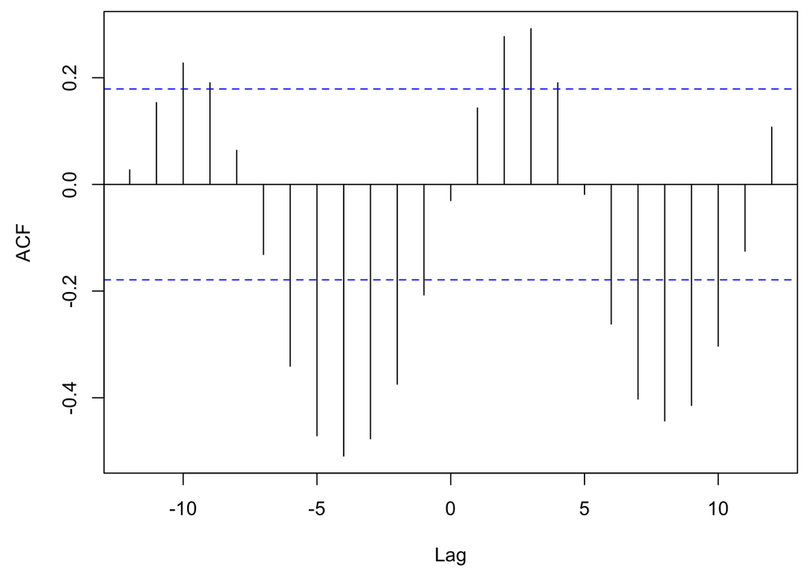

Cross-correlation plot of the two rotations.

```r
## set up plot area
par(mai = c(0.9,0.9,0.1,0.1))

## plot CCF's
ccf(proc_rot[1,],proc_rot[2,], lag.max = 12, main="")
```

# Plotting the data and model fits

We can now plot the fits for our DFA model along with the data.

**Tip:** The following function will return the model fitted values ± (1-$\alpha$)% confidence intervals.

```r
get_DFA_fits <- function(MLEobj, dd = NULL, alpha = 0.05) {
  ## empty list for results
  fits <- list()
  ## extra stuff for var() calcs
  Ey <- MARSS:::MARSShatyt(MLEobj)
  ## model params
    ZZ <- coef(MLEobj, type="matrix")$Z
    ## number of obs ts
    nn <- dim(Ey$ytT)[1]
    ## number of time steps
    TT <- dim(Ey$ytT)[2]
    ## get the inverse of the rotation matrix
    H_inv <- varimax(ZZ)$rotmat
    ## check for covars
    if(!is.null(dd)) {
      DD <- coef(MLEobj, type = "matrix")$D
      ## model expectation
      fits$ex <- ZZ %*% H_inv %*% MLEobj$states + DD %*% dd
    } else {
      ## model expectation
      fits$ex <- ZZ %*% H_inv %*% MLEobj$states
    }
    ## variance in model fits
    VtT <- MARSSkfss(MLEobj)$VtT
    VV <- NULL
    for(tt in 1:TT) {
      RZVZ <- coef(MLEobj, type = "matrix")$R - ZZ %*% VtT[,,tt] %*% t(ZZ)
      SS <- Ey$yxtT[,,tt] - Ey$ytT[,tt,drop = FALSE] %*% t(MLEobj$states[,tt,drop = FALSE])
      VV <- cbind(VV, diag(RZVZ + SS %*% t(ZZ) + ZZ %*% t(SS)))
      }
    SE <- sqrt(VV)
    ## upper & lower (1-alpha)% CI
    fits$up <- qnorm(1-alpha/2)*SE + fits$ex
    fits$lo <- qnorm(alpha/2)*SE + fits$ex
    return(fits)
}
```

**Task:** Plot the time series of the five phytoplankton groups with the mean of the DFA fits and the 95% confidence intervals.

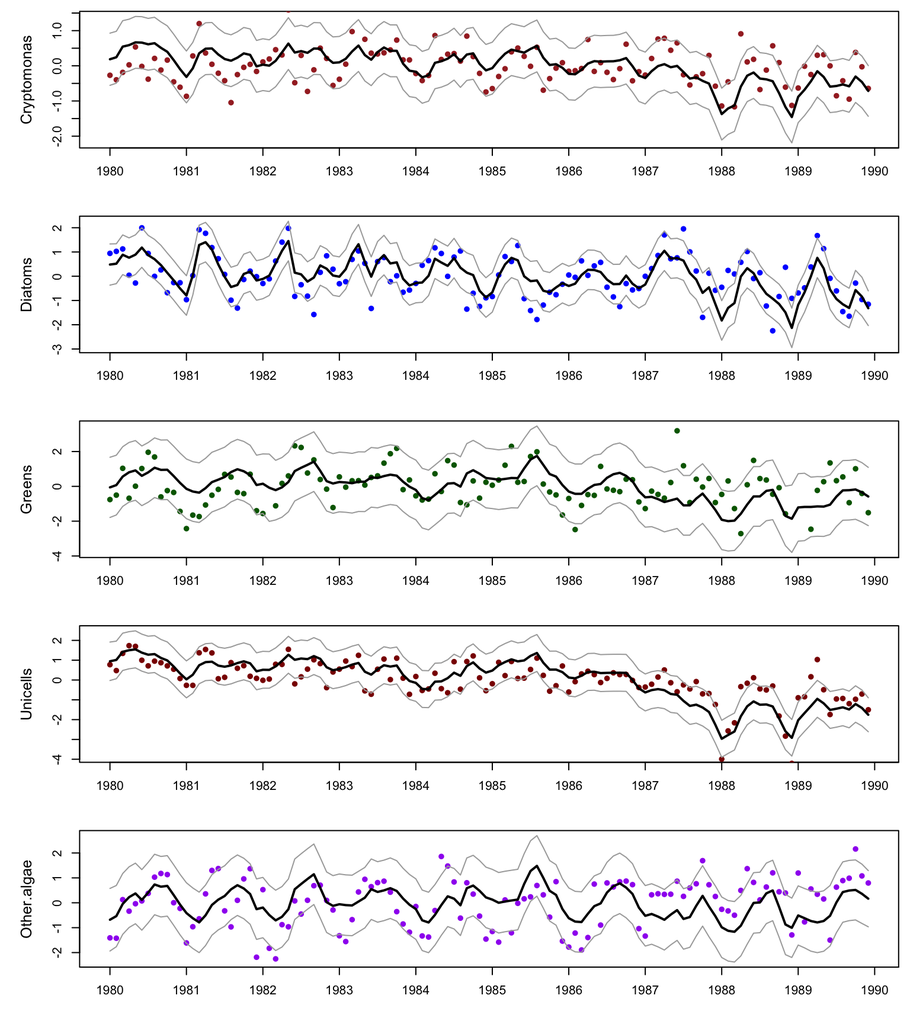

Data (points) and fits (black lines) from the DFA model.

```r
## get model fits & CI's
mod_fit <- get_DFA_fits(dfa_1)

## set up plotting area
par(mfrow = c(N_ts, 1), mai = c(0.5, 0.7, 0.1, 0.1), omi = c(0, 0, 0, 0))

## plot the fits
for(i in 1:N_ts) {
  up <- mod_fit$up[i,]
  mn <- mod_fit$ex[i,]
  lo <- mod_fit$lo[i,]
  plot(w_ts, mn, type = "n", ylim = c(min(lo), max(up)),
       cex.lab = 1.2,
       xlab = "", ylab = ylbl[i], xaxt = "n")
  axis(1, 12 * (0:dim(dat_1980)[2]) + 1, yr_frst + 0:dim(dat_1980)[2])
  points(w_ts,dat[i,], pch = 16, col = clr[i])
  lines(w_ts, up, col = "darkgray")
  lines(w_ts, mn, col = "black", lwd = 2)
  lines(w_ts, lo, col = "darkgray")
}
```

# Covariates in DFA models

It is standard to add covariates to the analysis so that one removes known important drivers. The DFA with covariates is written as:

$$\begin{equation}
\begin{gathered}
\mathbf{y}_t =
\mathbf{Z}\mathbf{x}_t+\mathbf{a}+\mathbf{D}\mathbf{d}_t+\mathbf{v}_t
\text{ where } \mathbf{v}_t \sim \text{MVN}(0,\mathbf{R}) \\
\mathbf{x}_t = \mathbf{x}_{t-1}+\mathbf{w}_t \text{ where } \mathbf{w}_t
\sim \text{MVN}(0,\mathbf{Q}) \\
\end{gathered}
\end{equation}$$

where the $q \times 1$ vector $\mathbf{d}_t$ contains the covariate(s) at time $t$, and the $n \times q$ matrix $\mathbf{D}$ contains the effect(s) of the covariate(s) on the observations.

**Tip:** Using `form = "dfa"` and `covariates = <covariate name(s)>`, we can easily add covariates to our DFA model, but this means that the covariates are input, not data, and there can be no missing values (see Chapter 6 in the {MARSS} User Guide for how to include covariates with missing values).

## Example from Lake Washington

The Lake Washington dataset has two environmental covariates that we might expect to have effects on phytoplankton growth, and hence, abundance:

1. Temperature (`Temp`)
2. Total phosphorous (`TP`)

**Tip:** We need the covariate inputs to have the same number of time steps as the variate data, and thus we limit the covariate data to the years 1980-1989 also.

```r
## get temperature and phosphorus covariates
temp <- t(plank_dat[,"Temp", drop = FALSE])
TP <- t(plank_dat[,"TP", drop = FALSE])
```

**Task:** Fit three different models that each add covariate effects (i.e., `Temp`, `TP`, `Temp` and `TP`) to our existing model above where $m$ = 3 and $\mathbf{R}$ is `"diagonal and unequal"`.

```r
## set up the model definition
mod_list = list(m = 3, R = "diagonal and unequal")

## fit model with temperature
dfa_temp <- MARSS(dat, model = mod_list, form = "dfa", z.score = FALSE,
                  control = con_list, covariates = temp)

## fit model with phosphorus
dfa_TP <- MARSS(dat, model = mod_list, form = "dfa", z.score = FALSE,
                control = con_list, covariates = TP)

## fit model with both temperature & phosphorus
dfa_both <- MARSS(dat, model = mod_list, form = "dfa", z.score = FALSE,
                  control = con_list, covariates = rbind(temp, TP))
```

**Task:** Compare whether the addition of the covariates improves the model fit.

```r
## print AICc values
print(cbind(model = c("no covars", "Temp", "TP", "Temp & TP"),
      AICc = round(c(dfa_1$AICc,
                     dfa_temp$AICc,
                     dfa_TP$AICc,
                     dfa_both$AICc))),
      quote = FALSE)
```

```
##      model     AICc
## [1,] no covars 1427
## [2,] Temp      1356
## [3,] TP        1414
## [4,] Temp & TP 1362
```

This suggests that adding temperature or phosphorus to the model, either alone or in combination with one another, does seem to improve overall model fit. If we were truly interested in assessing the “best” model structure that includes covariates, however, we should examine all combinations of 1-4 trends and different structures for $\mathbf{R}$.

**Task:** Fit a model with a dummy variable for season, and see how that compares to the others.

```r
## create dummy sine and cosine waves
cos_t <- cos(2 * pi * seq(TT) / 12)
sin_t <- sin(2 * pi * seq(TT) / 12)

## combine sine & cosine into one matrix
dd <- rbind(cos_t, sin_t)

## fit model
dfa_seas <- MARSS(dat, model = mod_list, form = "dfa", z.score = FALSE,
                  control = con_list, covariates = dd)
```

```
## Success! abstol and log-log tests passed at 451 iterations.
## Alert: conv.test.slope.tol is 0.5.
## Test with smaller values (<0.1) to ensure convergence.
##
## MARSS fit is
## Estimation method: kem
## Convergence test: conv.test.slope.tol = 0.5, abstol = 0.001
## Estimation converged in 451 iterations.
## Log-likelihood: -633.1283
## AIC: 1320.257   AICc: 1322.919
##
##                             Estimate
## Z.11                         0.26207
## Z.21                         0.24762
## Z.31                         0.03689
## Z.41                         0.51329
## Z.51                         0.18479
## Z.22                         0.04819
## Z.32                        -0.08824
## Z.42                         0.06454
## Z.52                         0.05905
## Z.33                         0.02673
## Z.43                         0.19343
## Z.53                        -0.10528
## R.(Cryptomonas,Cryptomonas)  0.14406
## R.(Diatoms,Diatoms)          0.44205
## R.(Greens,Greens)            0.73113
## R.(Unicells,Unicells)        0.19533
## R.(Other.algae,Other.algae)  0.50127
## D.(Cryptomonas,cos_t)       -0.23244
## D.(Diatoms,cos_t)           -0.40829
## D.(Greens,cos_t)            -0.72656
## D.(Unicells,cos_t)          -0.34666
## D.(Other.algae,cos_t)       -0.41606
## D.(Cryptomonas,sin_t)        0.12515
## D.(Diatoms,sin_t)            0.65621
## D.(Greens,sin_t)            -0.50657
## D.(Unicells,sin_t)          -0.00867
## D.(Other.algae,sin_t)       -0.62474
## Initial states (x0) defined at t=0
##
## Standard errors have not been calculated.
## Use MARSSparamCIs to compute CIs and bias estimates.
```

```r
## examine AICc
dfa_seas$AICc
```

```
## [1] 1322.919
```

The model with a dummy seasonal factor does much better than the covariate models. The model fits for the seasonal effects model are shown below.

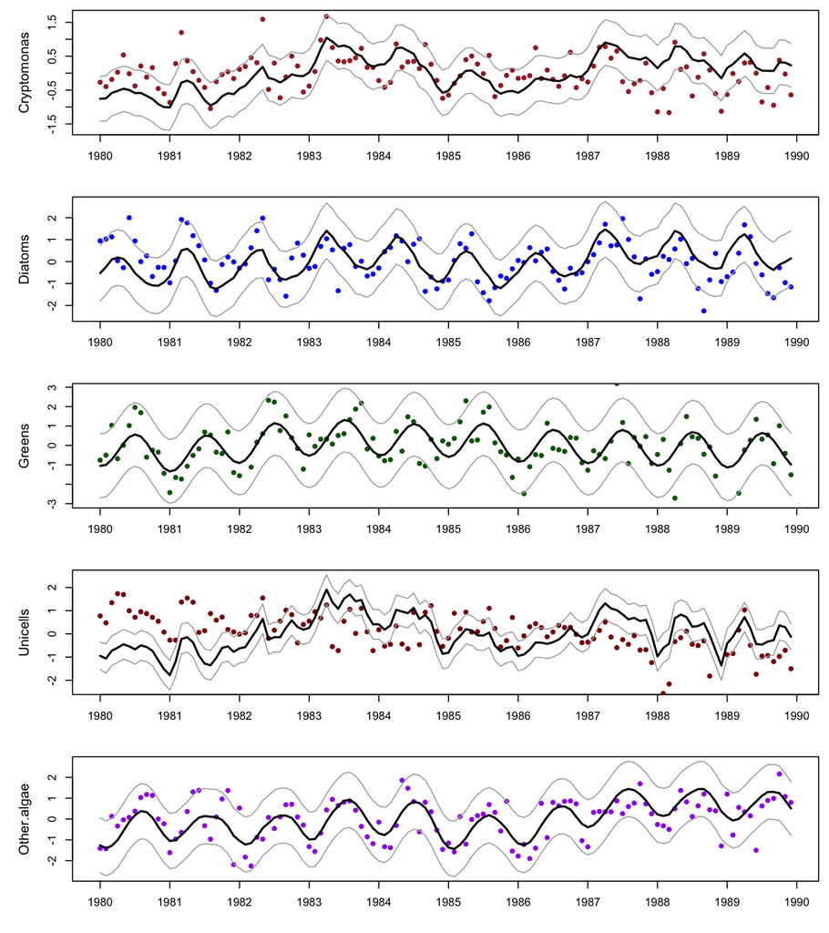

Data and model fits for the DFA with covariates.

```r
## get model fits & CI's
mod_fit <- get_DFA_fits(dfa_seas, dd = dd)

## plot the fits
par(mfrow = c(N_ts, 1), mai = c(0.5, 0.7, 0.1, 0.1), omi = c(0, 0, 0, 0))
for(i in 1:N_ts) {
  up <- mod_fit$up[i,]
  mn <- mod_fit$ex[i,]
  lo <- mod_fit$lo[i,]
  plot(w_ts, mn, type = "n",
       xlab = "", ylab = ylbl[i],
       xaxt = "n", cex.lab = 1.2,
       ylim = c(min(lo), max(up)))
  axis(1, 12 * (0:dim(dat_1980)[2]) + 1, yr_frst + 0:dim(dat_1980)[2])
  points(w_ts, dat[i,], pch = 16, col = clr[i])
  lines(w_ts, up, col = "darkgray")
  lines(w_ts, mn, col = "black", lwd = 2)
  lines(w_ts, lo, col = "darkgray")
}
```